# R Open Labs: Models

Nuvan Rathnayaka, University of North Carolina at Chapel Hill

March 28, 2019

## Data and other downloads

None.

```r
#install.packages("gridExtra")
library(gridExtra) #combining and organizing multiple ggplots
```

## Today

This workshop aims to introduce some **basic** intuition about modelling in R.

- [R for Data Science, Chapters 22-25](https://r4ds.had.co.nz/model-intro.html)

## Set up Your Project

Don’t forget to:

1. Create a new project in R
2. Create a data folder inside your project folder
3. Download the dataset (inspections10k.csv) to your data folder
4. Load the tidyverse

## Terminology

### What is a model?

A model is another tool to summarize the information in a dataset. This often comes in the form of approximations that make it easier to interpret and generalize relationships to new data. Ideally a model represents the “signal” in the data while ignoring unimportant or ungeneralizable “noise.”

For today we’ll mainly consider “supervised models”. A supervised model aims to predict some target variable(s) and requires that we have observed these variables alongside the factors we want to use to predict it. This target variable is sometimes called a “dependent” or “response” variable. Today’s lesson will focus on a specific form of supervised model, the linear model, also known as ordinary least squares regression (OLS) or the general linear model (not to be confused with generalized linear models).

Unsupervised models don’t distinguish between response and predictor variables and instead look for patterns among variables more generally. Clustering is one of the most commonly used unsupervised learning methods. We will not be covering unsupervised models today.

## Simple Linear Models with Plots

For these plots, we’ll use `moddf` provided via the code below. The `url` function combined with `read_csv` allows us to directly import content from the internet into our R session.

We’ll look at the code to generate `moddf` at the end of this section.

```r
moddf <- read_csv(url("https://github.com/UNC-Libraries-data/R-Open-Labs-ARCHIVE/raw/master/fall_2018/week8_Models/moddf.csv"))
head(moddf)
```

```
## # A tibble: 6 x 2
##       x     y
##   <dbl> <dbl>
## 1 10.6   36.1
## 2  5.67  24.1
## 3  8.67  35.8
## 4  7.46  15.9
## 5 12.4   34.3
## 6 12.2   42.0
```

Since these are both continuous numeric variables, let’s plot them with a scatterplot.

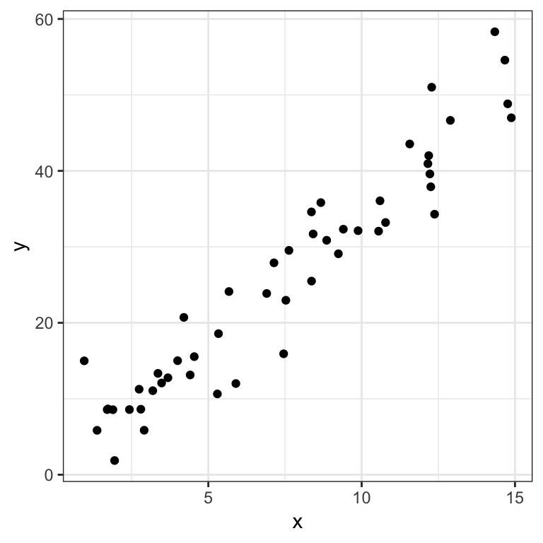

```r
ggplot(data=moddf,aes(x=x,y=y))+geom_point()+theme_bw()
```

One of the simplest ways to model data like this is with a line capturing the trend. We can model a line with an interpretable formula:

$$y= intercept + slope * x$$

Given a new `x` value, we could predict the corresponding `y` by plugging it into this equation. We can also get observations for the `x` values we have observed.

We can plot some candidate line(s) with `geom_abline`:

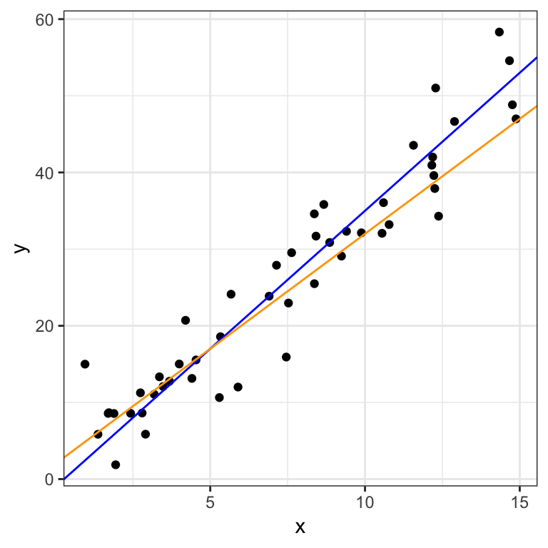

```r
ggplot(data=moddf,aes(x=x,y=y))+geom_point()+
  geom_abline(intercept=-1,slope=3.6,color="blue")+
  geom_abline(intercept=2,slope=3,color="orange")+
  theme_bw()
```

How do we choose between lines? A common metric, especially in prediction, involves measuring our misses with residuals:

residual = actual value - prediction

These can be graphically represented as lines parallel to the y-axis:

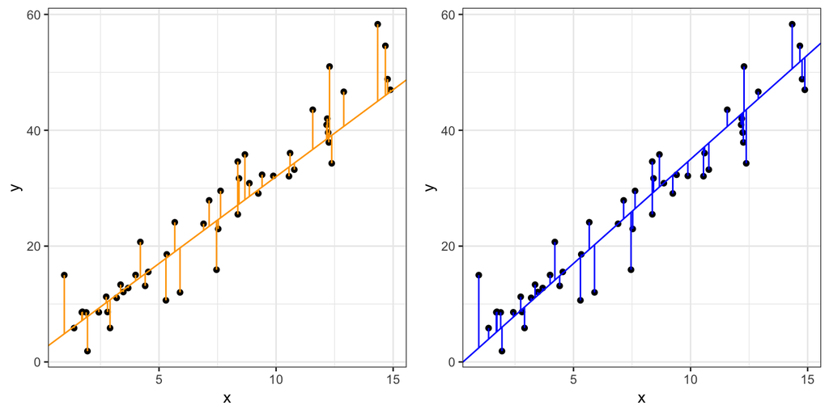

```r
moddf$p1 <- -1 + 3.6 * moddf$x
moddf$p2 <- 2 + 3 * moddf$x
plot1 <- ggplot(data=moddf,aes(x=x,y=y))+geom_point()+
  geom_abline(intercept=2,slope=3,color="orange")+
  geom_segment(aes(x = x, y = y,
                   xend = x, yend = p2),color="orange")+
  theme_bw()
plot2 <- ggplot(data=moddf,aes(x=x,y=y))+geom_point()+
  geom_abline(intercept=-1,slope=3.6,color="blue")+
  geom_segment(aes(x = x, y = y,
                   xend = x, yend = p1),color="blue")+
  theme_bw()
grid.arrange(plot1,plot2,ncol=2)
```

Ordinary Least Squares (OLS), often referred to simply as “Linear Regression”, finds the line that minimizes the sum of the squared residuals above.

We can fit an OLS with `lm` in R, and get a standard statistical summary with `summary`.

```r
fit <- lm(y ~ x, data = moddf)
summary(fit)
```

```
##
## Call:
## lm(formula = y ~ x, data = moddf)
##
## Residuals:
##     Min      1Q  Median      3Q     Max
## -9.8734 -2.6271 -0.1811  2.4935 10.9940
##
## Coefficients:
##             Estimate Std. Error t value Pr(>|t|)
## (Intercept)   0.8052     1.2915   0.623    0.536
## x             3.3514     0.1523  22.004   <2e-16 ***
## ---
## Signif. codes:  0 '***' 0.001 '**' 0.01 '*' 0.05 '.' 0.1 ' ' 1
##
## Residual standard error: 4.463 on 48 degrees of freedom
## Multiple R-squared:  0.9098, Adjusted R-squared:  0.9079
## F-statistic: 484.2 on 1 and 48 DF,  p-value: < 2.2e-16
```

The arguments given to `lm` are:

- Formula: `y~x`
- R uses `~` in place of the equals sign in formulas
- R automatically includes an intercept term
- This formula is therefore equivalent to:

$$y=intercept + slope * x$$
* Data: + The dataframe containing the variables of interest.

The values listed under `Estimate` provide estimates for the intercept,0.8051896, and slope,3.351441.

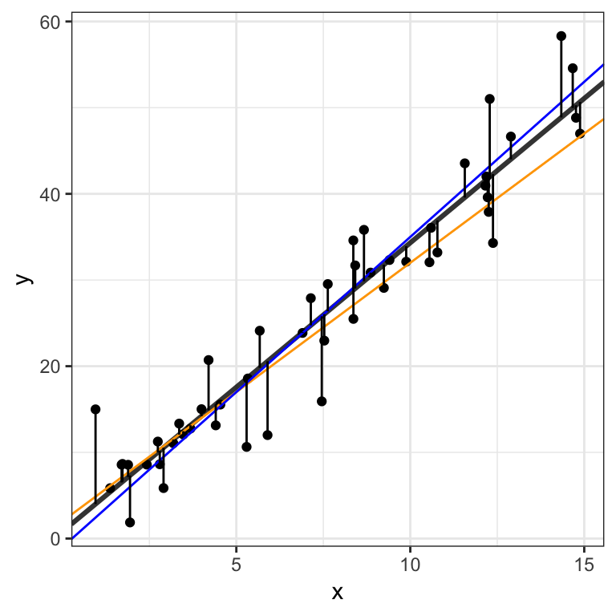

```r
moddf$lm <- predict(fit)
ggplot(data=moddf, aes(x=x, y=y)) +
  geom_point(color="black") +
  geom_abline(intercept=fit$coefficients[1],slope=fit$coefficients[2],size=1.1,alpha=0.8,color="black") +
  geom_abline(intercept=2,slope=3,color="orange")+
  geom_abline(intercept=-1,slope=3.6,color="blue")+
  geom_segment(aes(x = x, y = y,
                   xend = x, yend = lm)) +
  theme_bw()
```

We can visualize the OLS model’s point estimates and confidence bands like this:

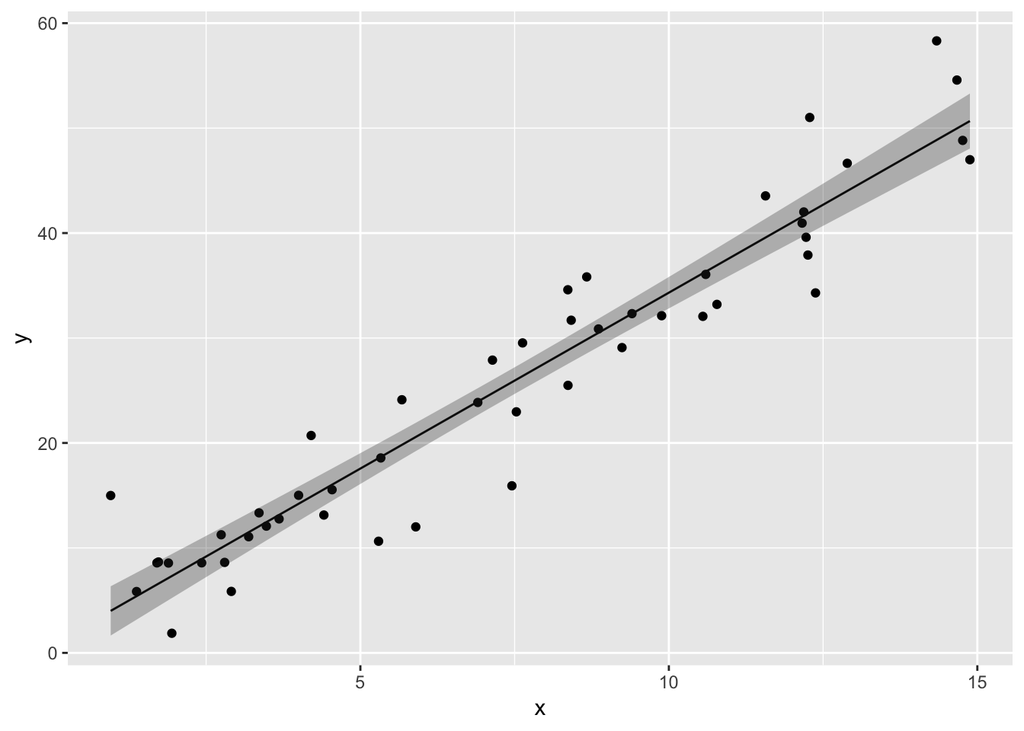

```r
moddf.predict <- cbind(moddf, predict(fit, interval = 'confidence'))

ggplot(moddf.predict, aes(x, y)) +
  geom_point() +
  geom_line(aes(x, lm)) +
  geom_ribbon(aes(ymin=lwr,ymax=upr), alpha=0.3)
```

Finally, here’s the code used to generate our dataset:

```r
x <- runif(50,0,15)
y <- 3.4 * x + rnorm(50,0,5)
moddf <- data.frame(x,y)
```

The “true” values, obscured by random noise, were:

- intercept = 0
- slope = 3.4

The OLS did a pretty good job determining these numbers. We’ll return to this idea of generating data in a bit.

## Multiple Regression - Formula notation in R

OLS can be extended to include multiple predictors. Let’s experiment with the built-in `mtcars` dataset.

```r
data(mtcars)
str(mtcars)
```

```
## 'data.frame':    32 obs. of  11 variables:
##  $ mpg : num  21 21 22.8 21.4 18.7 18.1 14.3 24.4 22.8 19.2 ...
##  $ cyl : num  6 6 4 6 8 6 8 4 4 6 ...
##  $ disp: num  160 160 108 258 360 ...
##  $ hp  : num  110 110 93 110 175 105 245 62 95 123 ...
##  $ drat: num  3.9 3.9 3.85 3.08 3.15 2.76 3.21 3.69 3.92 3.92 ...
##  $ wt  : num  2.62 2.88 2.32 3.21 3.44 ...
##  $ qsec: num  16.5 17 18.6 19.4 17 ...
##  $ vs  : num  0 0 1 1 0 1 0 1 1 1 ...
##  $ am  : num  1 1 1 0 0 0 0 0 0 0 ...
##  $ gear: num  4 4 4 3 3 3 3 4 4 4 ...
##  $ carb: num  4 4 1 1 2 1 4 2 2 4 ...
```

We add more variables with extentions to R’s formula notation:

| Symbol | Role | Example | Equivalent |
| --- | --- | --- | --- |
| `+` | Add variable | `mpg~vs+disp` | $$mpg = intercept + \beta_1 vs + \beta_2 disp$$ |
| `*` | Interactions | `mpg~vs*disp` | $$mpg = intercept + \beta_1 vs + \beta_2 disp + \beta_3 vs*disp$$ |
| `.` | Include all variables in dataframe | `mpg~.` | $$mpg = intercept + \beta_1 cyl + \beta_2 disp + ... + \beta_{10} carb$$ |
| `-` | Exclude variable | `mpg~.-disp-hp` | $$mpg = intercept + \beta_1 cyl + \beta_2 drat + ... + \beta_{8} carb$$ |

Examples:

```r
summary(lm(data=mtcars,mpg~vs+disp))
```

```
##
## Call:
## lm(formula = mpg ~ vs + disp, data = mtcars)
##
## Residuals:
##     Min      1Q  Median      3Q     Max
## -5.4605 -2.0260 -0.6467  1.7285  7.0790
##
## Coefficients:
##              Estimate Std. Error t value Pr(>|t|)
## (Intercept) 27.949282   2.201166  12.697 2.27e-13 ***
## vs           1.495004   1.651290   0.905    0.373
## disp        -0.036896   0.006715  -5.494 6.43e-06 ***
## ---
## Signif. codes:  0 '***' 0.001 '**' 0.01 '*' 0.05 '.' 0.1 ' ' 1
##
## Residual standard error: 3.261 on 29 degrees of freedom
## Multiple R-squared:  0.7261, Adjusted R-squared:  0.7072
## F-statistic: 38.44 on 2 and 29 DF,  p-value: 7.005e-09
```

We can use some familiar tidyverse tool to visualize this fit:

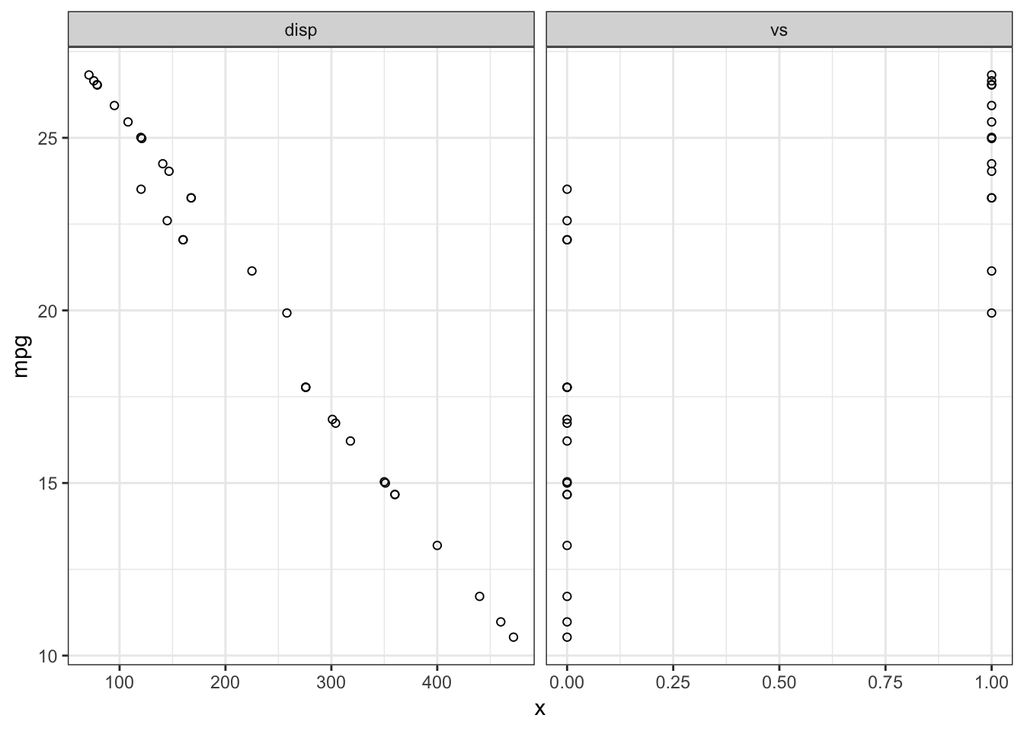

```r
d <- mtcars %>% select(mpg, vs, disp)
fit2 <- lm(mpg ~ vs + disp, data = d)
d$predicted <- predict(fit2)
d$residuals <- residuals(fit2)


d %>%
  gather(key = "iv", value = "x", -mpg, -predicted, -residuals) %>%
  ggplot(aes(x = x, y = mpg)) +
  geom_point(aes(y = predicted), shape = 1) +
  facet_grid(~ iv, scales = "free") +
  theme_bw()
```

What does `-1` do below?

```r
summary(lm(data=mtcars,mpg~vs*hp+disp-1))
```

```
##
## Call:
## lm(formula = mpg ~ vs * hp + disp - 1, data = mtcars)
##
## Residuals:
##      Min       1Q   Median       3Q      Max
## -10.4960  -3.2474  -0.3531   4.3101  19.0605
##
## Coefficients:
##         Estimate Std. Error t value Pr(>|t|)
## vs    38.9990553  7.2131470   5.407 9.13e-06 ***
## hp     0.0757879  0.0261494   2.898  0.00721 **
## disp   0.0003558  0.0159033   0.022  0.98231
## vs:hp -0.2343856  0.0769152  -3.047  0.00500 **
## ---
## Signif. codes:  0 '***' 0.001 '**' 0.01 '*' 0.05 '.' 0.1 ' ' 1
##
## Residual standard error: 6.733 on 28 degrees of freedom
## Multiple R-squared:  0.9096, Adjusted R-squared:  0.8967
## F-statistic: 70.44 on 4 and 28 DF,  p-value: 3.339e-14
```

## Modeling

You can learn more about common extensions to linear models in R For Data Science:

- [Categorical Variables, 23.4.1](https://r4ds.had.co.nz/model-basics.html#categorical-variables)
- Interactions, [23.4.2](https://r4ds.had.co.nz/model-basics.html#interactions-continuous-and-categorical)-[23.4.3](https://r4ds.had.co.nz/model-basics.html#interactions-two-continuous)
- [Transformations, 23.4.4](https://r4ds.had.co.nz/model-basics.html#transformations) Linear models alone are often the foundation for an entire semester long course; taught in a variety of discipline-specific settings as well as the Biostatistics and Statistics and Operations Research departments.

## Simulations

There’s a very powerful idea hidden in the bit of code we used to generate the first dataset:

```r
x <- runif(50,0,15)
y <- 3.4 * x + rnorm(50,0,5)
moddf <- data.frame(x,y)
```

This block of code *generates* random data according to our specifications. Unlike most fields of science, where you have to actively gather data, statisticians can use random number generators. This underlies the most commonly used computational tool in statistics: the simulation study.

In a typical simulation study we **Generate** data according to a known data generation process. Then we **Analyze** data using the method we want to investigate. Finally we **Summarize** the simulation study using either tables or graphs.

Let’s use this tool to study the sampling distribution of a regression slope using the same data generating process as before:

- intercept = 0
- slope = 3.4

### Sample size and the sampling distribution of the regression slope

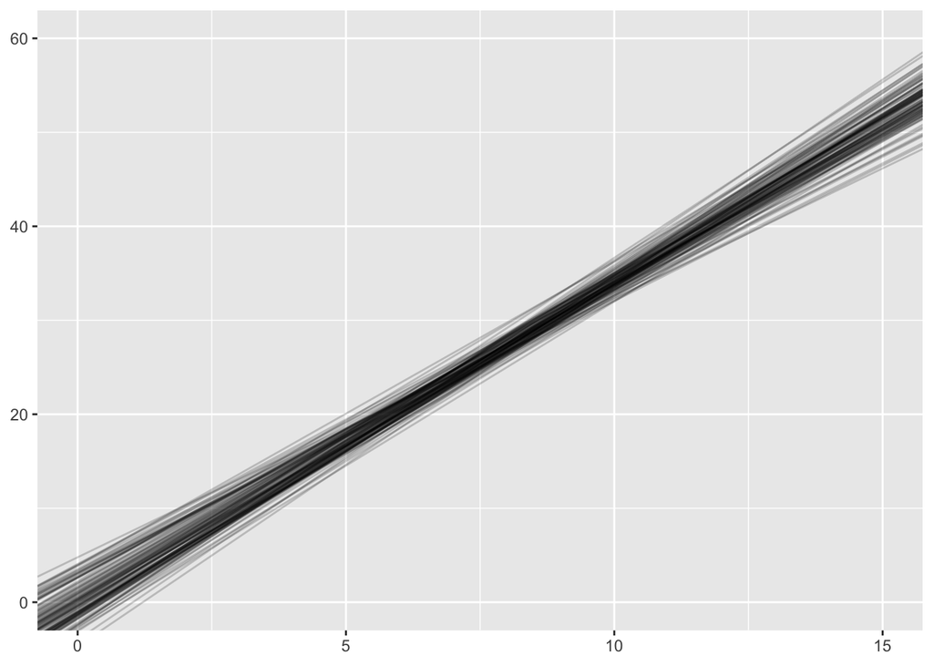

```r
nsims <- 100
sample_size <- 32
int <- vector("numeric", nsims)
sl <- vector("numeric", nsims)
for (i in 1:nsims){
  #Generate
  x <- runif(sample_size,0,15)
  y <- 3.4 * x + rnorm(sample_size,0,5)
  moddf <- data.frame(x,y)

  #Analyze
  fit <- lm(y ~ x, data = moddf)
  int[i] <- coef(fit)[1]
  sl[i] <- coef(fit)[2]
}

sim_results <- data.frame(int, sl)

#Summarize
ggplot(sim_results) +
  geom_abline(intercept=int, slope=sl, alpha = 0.2) +
  xlim(0, 15) +
  ylim(0, 60)
```

What happens if we change the sample size within each simulation from 32 to 8?

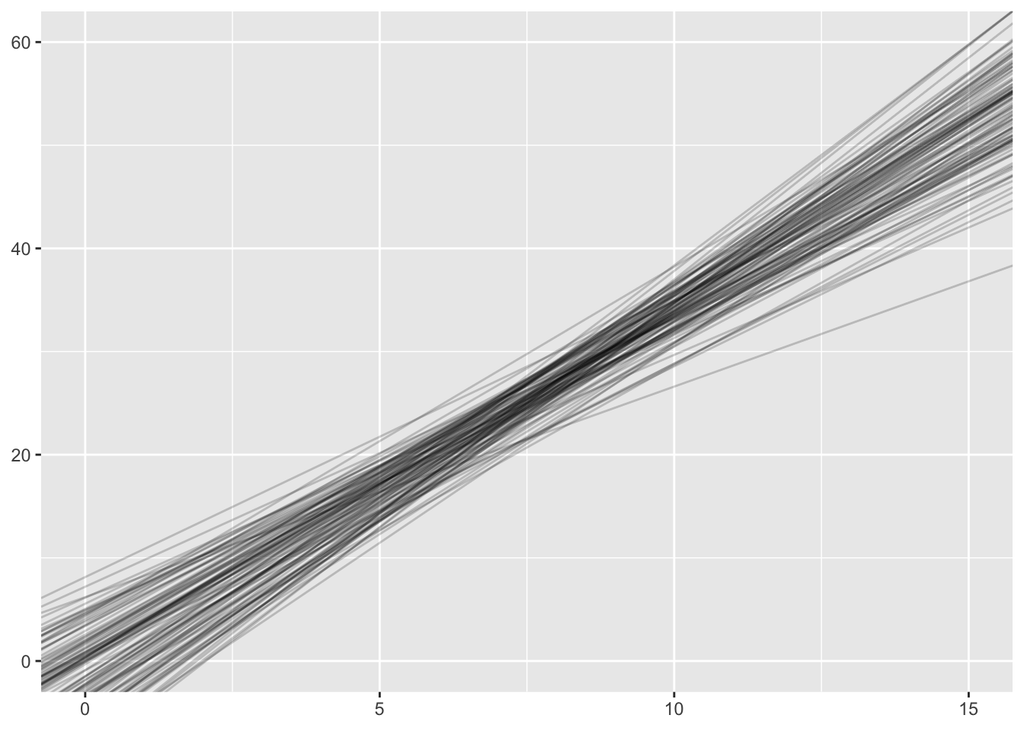

```r
nsims <- 100
sample_size <- 8
int <- vector("numeric", nsims)
sl <- vector("numeric", nsims)
for (i in 1:nsims){
  x <- runif(sample_size, 0, 15)
  y <- 3.4 * x + rnorm(sample_size, 0, 5)
  moddf <- data.frame(x,y)

  fit <- lm(y ~ x, data = moddf)
  int[i] <- coef(fit)[1]
  sl[i] <- coef(fit)[2]
}

sim_results <- data.frame(int, sl)

ggplot(sim_results) +
  geom_abline(intercept=int, slope=sl, alpha = 0.2) +
  xlim(0, 15) +
  ylim(0, 60)
```

What happens if we change the sample size within each simulation to 1024?

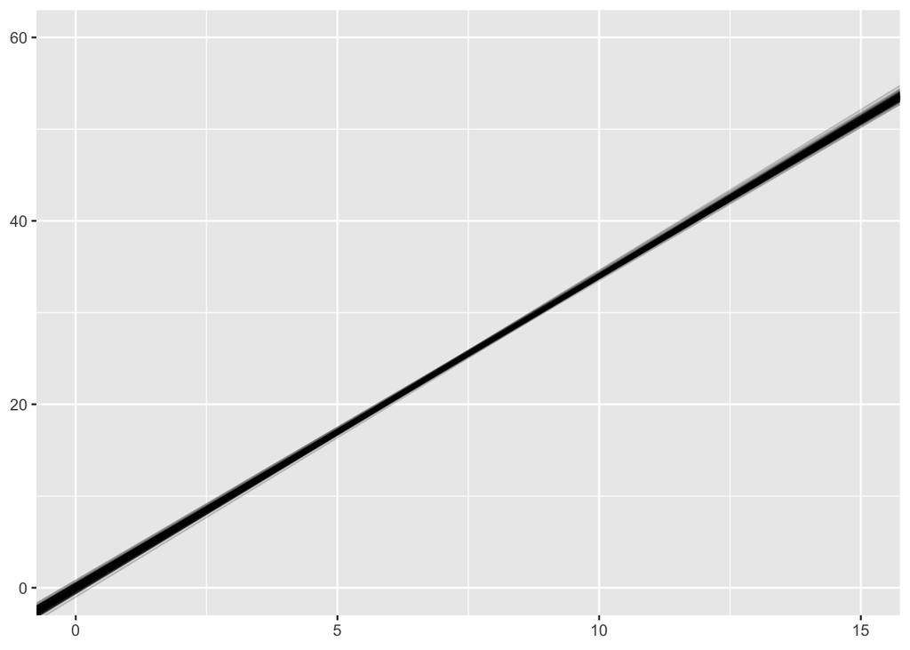

```r
nsims <- 100
sample_size <- 1024
int <- vector("numeric", nsims)
sl <- vector("numeric", nsims)
for (i in 1:nsims){
  x <- runif(sample_size, 0, 15)
  y <- 3.4 * x + rnorm(sample_size, 0, 5)
  moddf <- data.frame(x,y)

  fit <- lm(y ~ x, data = moddf)
  int[i] <- coef(fit)[1]
  sl[i] <- coef(fit)[2]
}

sim_results <- data.frame(int, sl)

ggplot(sim_results) +
  geom_abline(intercept=int, slope=sl, alpha = 0.2) +
  xlim(0, 15) +
  ylim(0, 60)
```

### What is a 95% confidence interval?

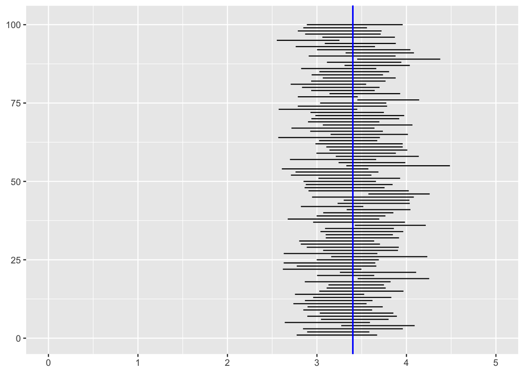

```r
nsims <- 100
sample_size <- 32
index <- vector("numeric", nsims)
lower <- vector("numeric", nsims)
upper <- vector("numeric", nsims)
for (i in 1:nsims){
  x <- runif(sample_size, 0, 15)
  y <- 3.4 * x + rnorm(sample_size, 0, 5)
  moddf <- data.frame(x,y)
  fit <- lm(y ~ x, data = moddf)
  index[i] <- i
  lower[i] <- confint(fit)[2,1]
  upper[i] <- confint(fit)[2,2]
}

sim_results <- data.frame(index, lower, upper)

ggplot(sim_results) +
  geom_segment(y = index, yend = index, x = lower, xend = upper) +
  geom_segment(y = -5, yend = 110, x = 3.4, xend = 3.4, color = "blue") +
  xlim(0, 5) +
  ylim(0,101)
```

The confidence level (say 95%) of a confidence interval does not apply to a particular confidence interval. Rather, it applies to the procedure. If you collect one sample of data, fit a model, and the look at the confidence interval, the true value is either inside that interval or it is not (unfortunately, we usually don’t know whether the true value is inside the interval). However, if you repeat the study 1000 times and fit precisely the same model to each of those 1000 datasets, about 95% of the 1000 confidence intervals you estimate will contain the true value.

Of course, this is all assuming you are fitting the correct model, but that is a discussion beyond the scope of this workshop!

## Reproducible simulations

Much of our focus this semester has been on reproducible workflows and reproducible reports. How can we make a simulation study reproducible when it involves generating random numbers? The random number generators in R are actually pseudo-random number generators. They take a **seed** value and then generate a sequence of number that are randomly drawn from a given distribution, but if you use the same seed, the sequence of number will be exactly the same. If you run the following code, you should get the same five lines that are present on this webpage.

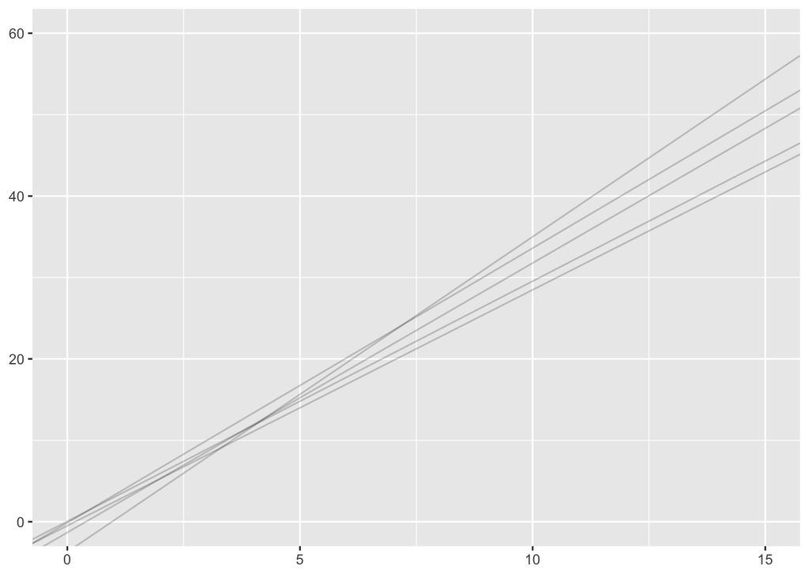

```r
set.seed(1234)
nsims <- 5
sample_size <- 8
int <- vector("numeric", nsims)
sl <- vector("numeric", nsims)
for (i in 1:nsims){
  x <- runif(sample_size, 0, 15)
  y <- 3.4 * x + rnorm(sample_size, 0, 5)
  moddf <- data.frame(x,y)

  fit <- lm(y ~ x, data = moddf)
  int[i] <- coef(fit)[1]
  sl[i] <- coef(fit)[2]
}

sim_results <- data.frame(int, sl)

ggplot(sim_results) +
  geom_abline(intercept=int, slope=sl, alpha = 0.2) +
  xlim(0, 15) +
  ylim(0, 60)
```

## Exercises

1. Explore the datasets included with the built-in `datasets` package by running `data(package="datasets")`. You can get more information about any given dataset with `?<dataset name>`. Choose a dataset with at least a few numeric variables.
2. Use `str`, `head`, `summary` and any of our EDA techniques to explore the dataset. Pick a continuous outcome variable of interest and choose some predictors.
3. Fit an `lm` with your selected variables.
4. Use your intial `lm` fit to create a [stargazer table](https://unc-libraries-data.github.io/R-Open-Labs/Extras/Stargazer/Stargazer.html) output. Embed in an R Markdown document or output html. Use `?stargazer` to learn about and then change one or more default settings.

## Feedback

[Let us know what you think of this lesson!](https://unc.az1.qualtrics.com/jfe/form/SV_8e1zRY2rlFUYBMx)